# Klasse-E slides

Klasse E versterkers

Hoogfrequent versterkers  
met 1 vermogentransistor

Jan Genoe

Oktober 2025

###### Basisschema Klasse E versterker

[figure not shown]

###### Resonante seriekring van de klasse E versterker

[figure not shown]

###### Stroom in resonante seriekring

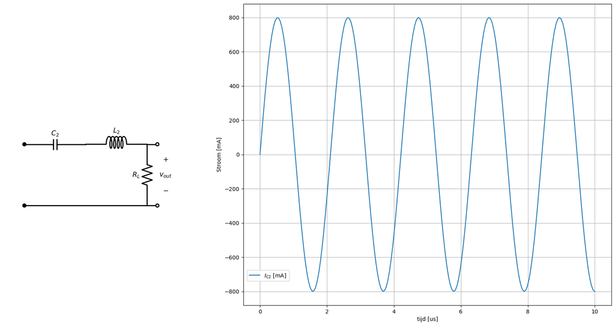

###### Voeding met DC stroom door L1

[figure not shown]

###### Voeding met DC stroom door L1

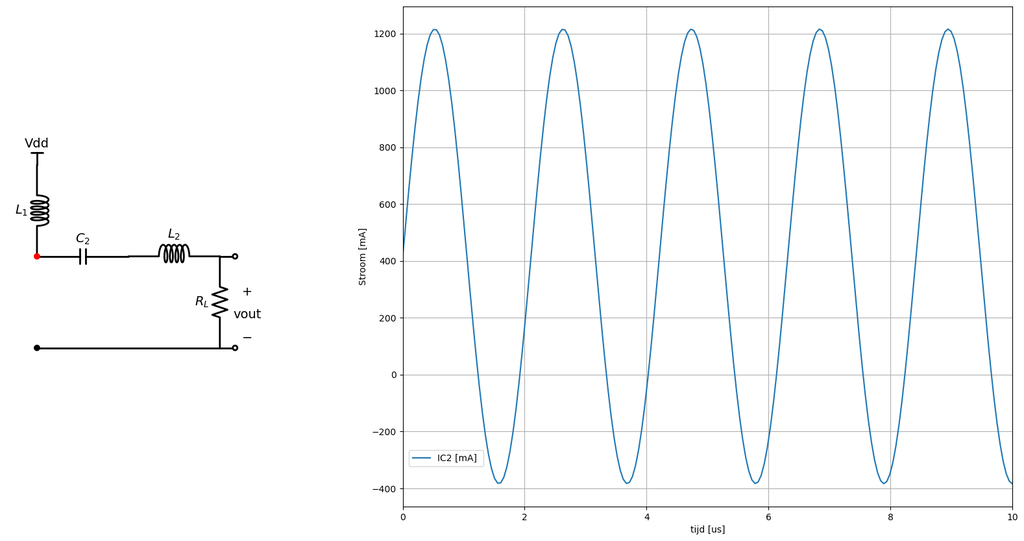

###### Integratie stroom op C1

[figure not shown]

###### Integratie stroom op C1

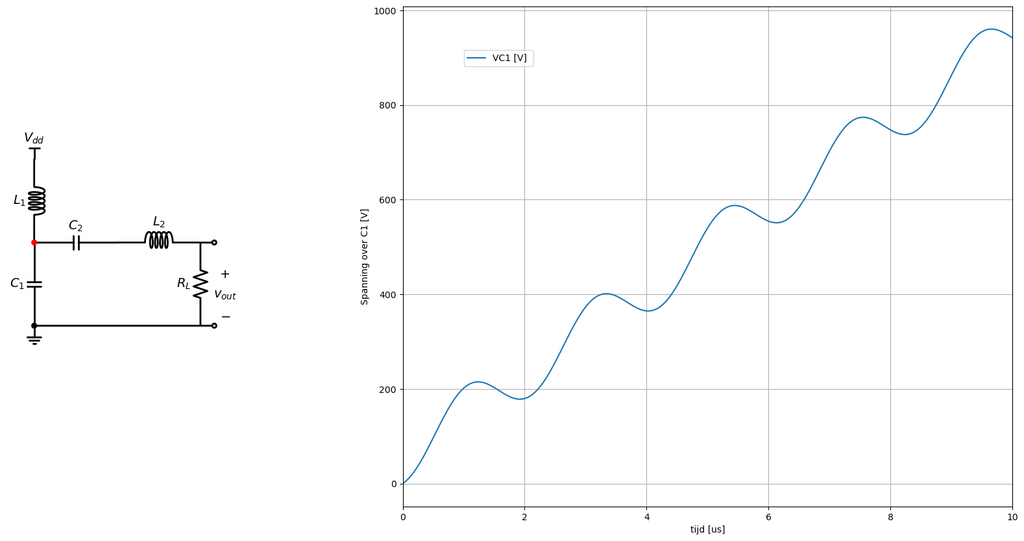

###### Integratie stroom op C1

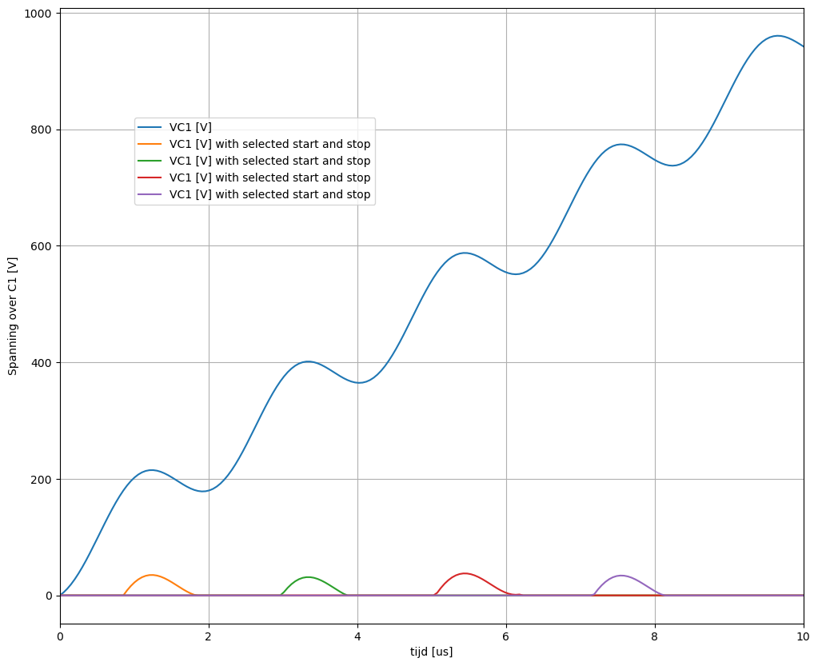

###### Transistor om de spanning op 0 te houden

[figure not shown]

###### Spanning na integratie stroom op C1

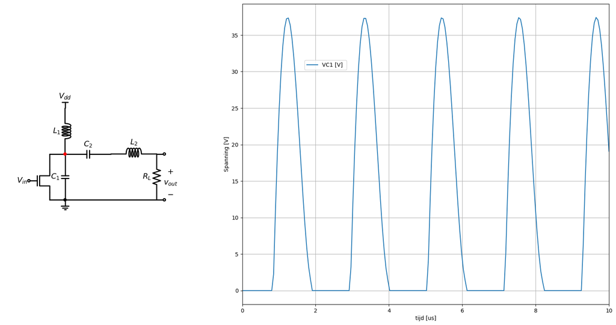

###### Klasse E met derde harmonische filter

[figure not shown]

###### Voorbeeld 1 : Opgave

- **Verwacht vermogen** : 5W
- **Frequentie** : 475 kHz
- **Voedingsspanning** : 12.5 V
- **Kwaliteitsfactor** : 5
- **Saturatiespanning** 0.5V

###### Voorbeeld1 : berekende elementen

```
RL = 14.88 Ohm
C₁ = 4.78 nF (i.e. complexe impedantie van -70.07 i Ohm)
C₂ = 6.04 nF (i.e. complexe impedantie van -55.50 i Ohm)
L₂ = 24.93 uH (i.e. complexe impedantie van 74.39 i Ohm)
Totale complexe impedantie (seriekring):  18.89 i Ohm
Maximale stroom uit de voeding: 416.67 mA
Maximale source-drain spanning (transistor): 55.62 V
Hierbij werd een 80% veiligheidsmarge genomen
We kunnen de uitgang omwerken naar een impedantie van 50 Ohm
door een transformator met wikkelverhouding: 1.83
```

###### Voorbeeld 1: Bekomen schema

[figure not shown]

###### Voorbeeld1 : Spice file

```
* Class E amp 1
M_M1         2 1 0 0 FDB33N25
L_L1         2 3  1000uH
C_C1         2 0  4.78nF
L_L2         4 5  24.93uH
C_C2         2 4  6.04nF
R_RL         5 0  14.88
V_Vdd        3 0 12.5V
V_Vin        1 0 PULSE(0 9 1.05u 20n 20n 1.05u 2.10526u) DC=0
.model FDB33N25 VDMOS(Rg=3 Rd=40m Rs=27m Vto=5.35 Kp=35 lambda=.05 Cgdmax=1.1n Cgdmin=25p Cgs=1.7n Cjo=800p Is=7.94p Rb=7m mfg=Fairchild Vds=250 Ron=94m Qg=37n)
```

###### Voorbeeld 1: Verloop spanningen (opstarten oscillatie)

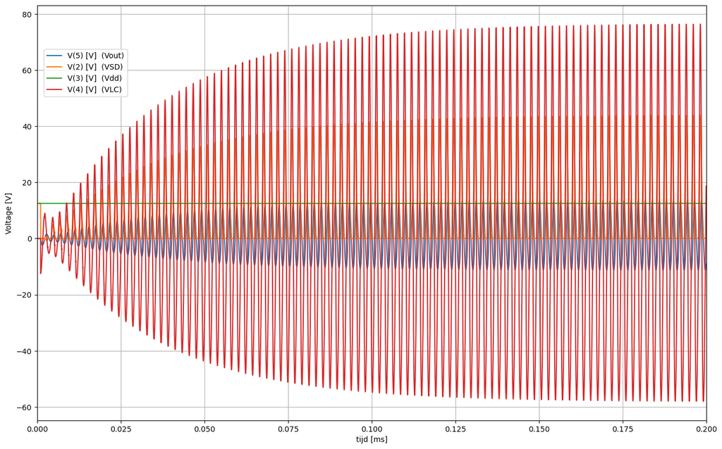

###### Voorbeeld 1: detail van de opstart

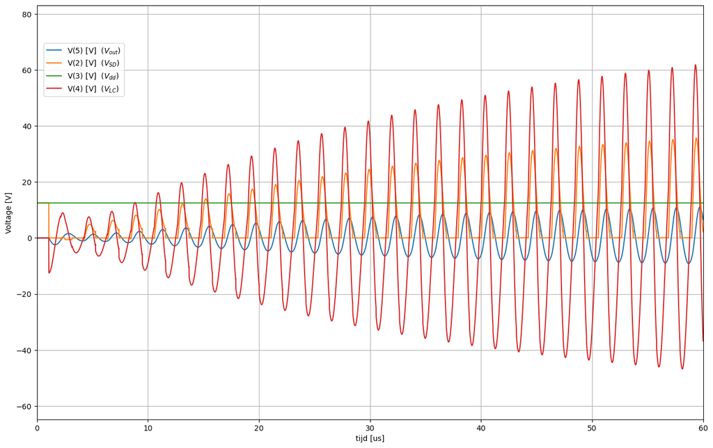

###### Voorbeeld 1: detail 1 periode

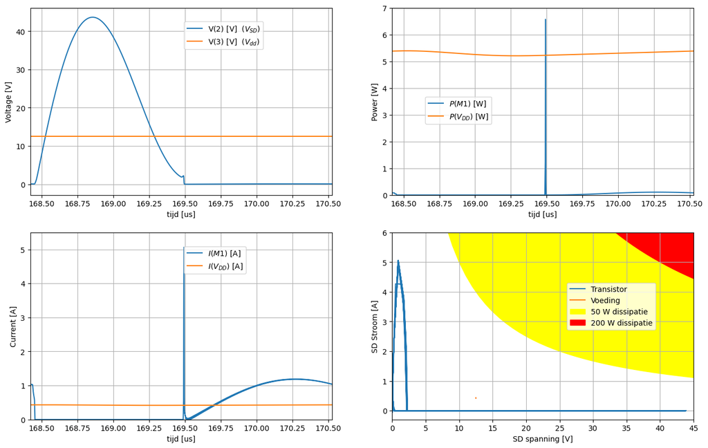

###### Voorbeeld 1: Schema met aanpassing 50 Ohm coax

[figure not shown]

###### Voorbeeld 2 : Opgave

- **Verwacht vermogen** : 50W
- **Frequentie** : 137.77 kHz
- **Voedingsspanning** : 12.5 V
- **Kwaliteitsfactor** : 5
- **Saturatiespanning** 0.9V

###### Voorbeeld 2: waardes componenten

```
RL = 1.39 Ohm
C₁ = 176.90 nF (i.e. complexe impedantie van -6.53 i Ohm)
C₂ = 222.56 nF (i.e. complexe impedantie van -5.19 i Ohm)
L₂ = 8.03 uH (i.e. complexe impedantie van 6.95 i Ohm)
Totale complexe impedantie (seriekring):  1.76 i Ohm
Maximale stroom uit de voeding: 4310.34 mA
Maximale source-drain spanning (transistor): 55.62 V
Hierbij werd een 80% veiligheidsmarge genomen
We kunnen de uitgang omwerken naar een impedantie van 50 Ohm
door een transformator met wikkelverhouding: 6.00
```

###### Voorbeeld 2: Bekomen schema

[figure not shown]

###### Voorbeeld 2: aanpassing 50 Ohm

[figure not shown]

###### Voorbeeld 2: SPICE file

```
* Class E amp 1
M_M1         2 1 0 0 FDB33N25
L_L1         2 3  270uH
C_C1         2 0  176.9nF
L_L2         4 5  8.03uH
C_C2         2 4  222.56nF
R_RL         5 0  1.39
V_Vdd        3 0 12.5V
V_Vin        1 0 PULSE(0 9 3.65u 20n 20n 3.65u 7.3u) DC=0
.model FDB33N25 VDMOS(Rg=3 Rd=40m Rs=27m Vto=5.35 Kp=35 lambda=.05 Cgdmax=1.1n Cgdmin=25p Cgs=1.7n Cjo=800p Is=7.94p Rb=7m mfg=Fairchild Vds=250 Ron=94m Qg=37n)
```

###### Voorbeeld 2: bekomen oscillatie

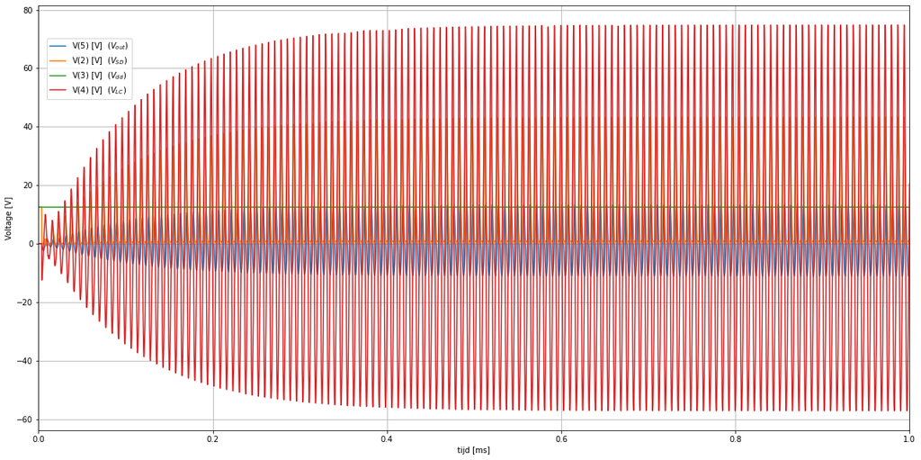

###### Voorbeeld 2: detail opstartsequentie

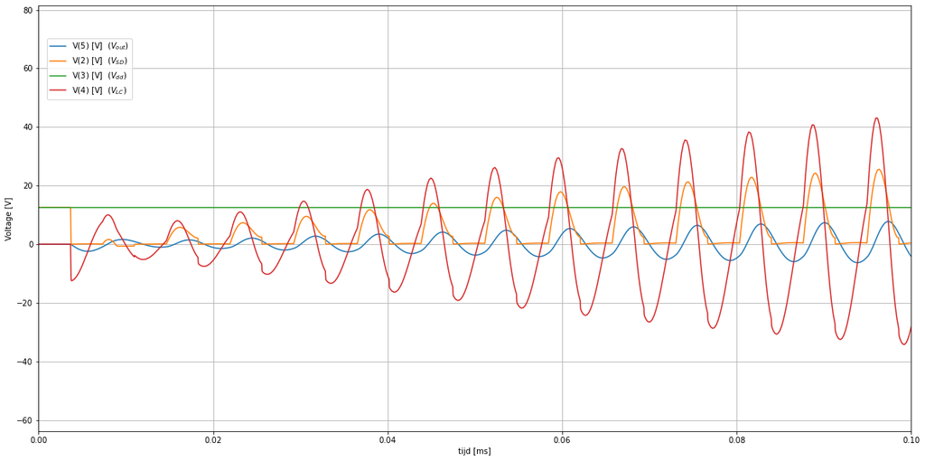

###### Voorbeeld 2: 1 periode van de Steady State

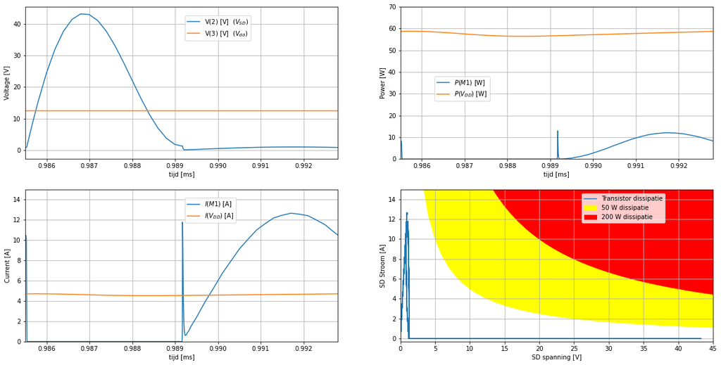

###### Voorbeeld 3: Klasse E met injection locking

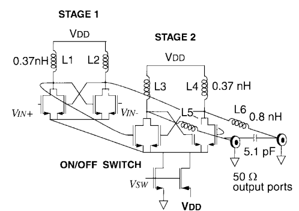

###### Voorbeeld 3: SPICE file Klasse E circuit met injection locking

```
* Class E Tsai
M_SWn        0 11 10 0 nmos W=31580u L=0.35u
M_SWp        3 11 10 3 pmos W=500u L=0.35u
* stage 1
L_L1         3 6  0.37nH
L_L2         3 7  0.37nH
M_11         10 1 6 0 nmos W=980u L=0.35u
M_12         10 7 6 0 nmos W=980u L=0.35u
M_13         10 6 7 0 nmos W=980u L=0.35u
M_14         10 2 7 0 nmos W=980u L=0.35u
* stage 2
M_21         10 6 8 0 nmos W=3600u L=0.35u
M_22         10 9 8 0 nmos W=4800u L=0.35u
M_23         10 8 9 0 nmos W=4800u L=0.35u
M_24         10 7 9 0 nmos W=3600u L=0.35u
L_L3         3 8  0.37nH
L_L4         3 9  0.37nH
L_L5         8 4  0.8nH
L_L6         9 5  0.8nH
C_C1         4 5  5.1pF
* belasting
R_RL1        4 0  50
R_RL2        5 0  50
.include simul/berkeley35.lib
```

###### Voorbeeld 3: simulatie Klasse E circuit met injection locking

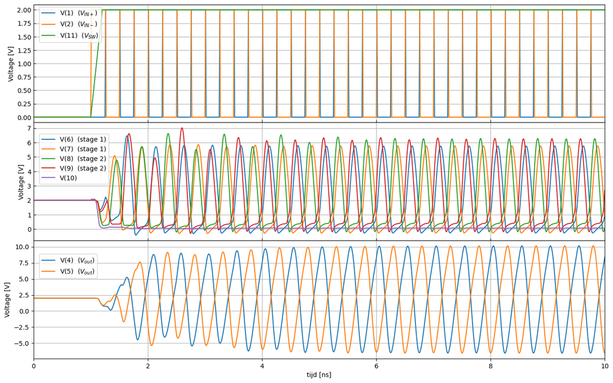

###### Voorbeeld 3: 1 periode M21

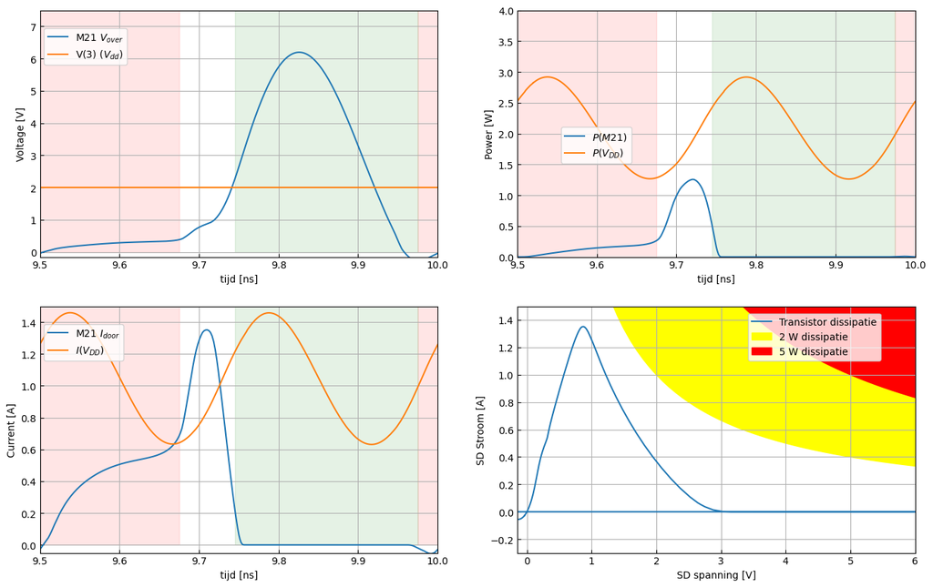

###### Voorbeeld 3: 1 periode M22

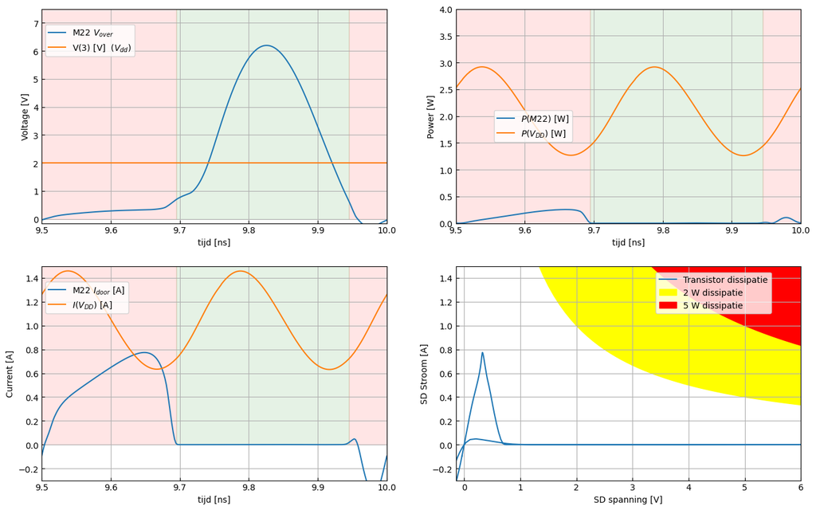

###### Belangrijkste Eigenschappen van Klasse E Versterkers

De klasse E versterker biedt verschillende belangrijke voordelen:

- **Efficiëntie:**
  - Theoretisch tot 100% efficiëntie mogelijk
  - Praktisch 85-95% haalbaar
  - Ideaal voor batterij-gevoede toepassingen
- **Frequentiebereik:**
  - Optimaal voor hoogfrequent toepassingen (MHz-GHz)
  - Beperkte bandbreedte rond resonantiefrequentie
  - Geschikt voor narrowband communicatie
- **Implementatie:**
  - Eenvoudige topologie met één transistor
  - Kritische timing tussen spanning en stroom
  - Nauwkeurige componentwaarden vereist

###### Toepassingsgebieden

- **Moderne Communicatiesystemen:**
  - GSM/UMTS/LTE zendversterkers
  - WiFi en Bluetooth transmitters
  - RFID en NFC systemen
  - Satellietcommunicatie
- **Vooruitblik:**
  - 5G millimeter-golf toepassingen
  - IoT low-power transmitters
  - Draadloze energieoverdracht
  - Geïntegreerde on-chip oplossingen

I would rather have questions that can't be answered  
than answers that can't be questioned.

Richard Feynman